# Bike Sharing Dataset

### by temperature and feeling temperature (atemp)

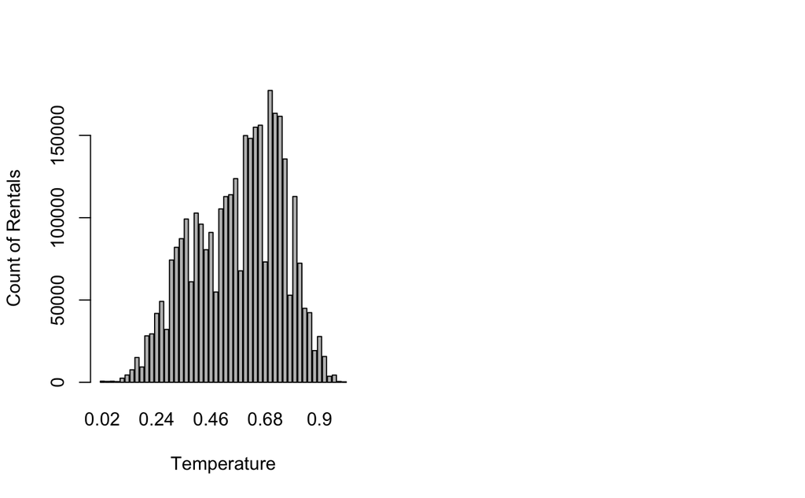

```r
par(mfrow = c(1,2))

barplot(tapply(bike$cnt, bike$temp, sum), beside = TRUE,
        xlab = "Temperature",
        ylab = "Count of Rentals")

barplot(tapply(bike$cnt, bike$atemp, sum), beside = TRUE,
        xlab = "Feeling temperature",
        ylab = "Count of Rentals")
```

Temperature in C

Normalized temperature by the following formula: (t-t_min)/(t_max-t_min) t_min = -8 t_max = +39

Feeling Temperature in C

Normalized temperature by the following formula: (t-t_min)/(t_max-t_min) t_min = -16 t_max = +50

The distribution is left-skewed. That means that people tend to rent our bikes on more warm days, but not on burning hot days!

### by humidity

Normalized humididty. The values are divided to 100 (max)

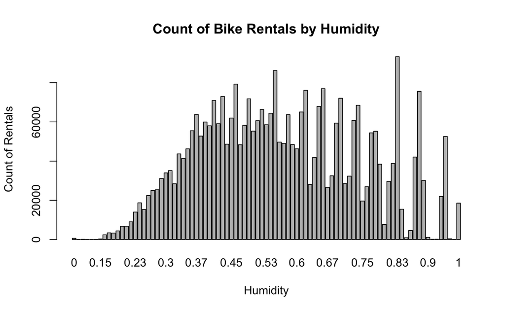

```r
barplot(tapply(bike$cnt, bike$hum, sum), beside = TRUE,
        main = "Count of Bike Rentals by Humidity",
        xlab = "Humidity",
        ylab = "Count of Rentals")
```

Most rentals in humidity range of 0.30 to 0.70

### by wind speed

Normalized wind speed. The values are divided to 67 (max)

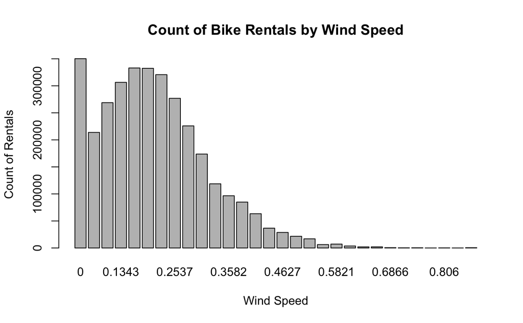

```r
barplot(tapply(bike$cnt, bike$windspeed, sum), beside = TRUE,
        main = "Count of Bike Rentals by Wind Speed",
        xlab = "Wind Speed",
        ylab = "Count of Rentals")
```

# Data pre-processing before training

## Fixing categorical variables

**IN THE PROJECT PRESENTATION IT WAS MENTIONED THAT WE SHOULD CONVERT OUR CATEGORICAL VARIABLES TO FACTORS. THE REASON WAS THE INITIAL LINIEAR ASSUMPTION IN LINEAR REGRESSION MODEL. THEREFORE, WE CONVERT ALL CATEGORICAL VARIABLES TO FACTORS**

- season : season (1:winter, 2:spring, 3:summer, 4:fall)
  - mnth : month ( 1 to 12)
  - hr : hour (0 to 23)
  - holiday : weather day is holiday or not (extracted from http://dchr.dc.gov/page/holiday-schedule)
  - weekday : day of the week
  - workingday : if day is neither weekend nor holiday is 1, otherwise is 0.
  - weathersit 1,2,3,4.

```r
# Convert 'season' to a factor
bike$season <- factor(bike$season, levels = c(1, 2, 3, 4), labels = c("winter", "spring", "summer", "fall"))

# Convert 'mnth' to a factor
bike$mnth <- factor(bike$mnth)

# Convert 'hr' to a factor
bike$hr <- factor(bike$hr)

# Convert 'holiday' to a factor
bike$holiday <- factor(bike$holiday, levels = c(0, 1), labels = c("not_holiday", "holiday"))

# Convert 'weekday' to a factor
bike$weekday <- factor(bike$weekday, levels = c(0, 1, 2, 3, 4, 5, 6), labels = c("Sunday", "Monday", "Tuesday", "Wednesday", "Thursday", "Friday", "Saturday"))

# Convert 'workingday' to a factor
bike$workingday <- factor(bike$workingday, levels = c(0, 1), labels = c("weekend/holiday", "working_day"))

# Convert 'weathersit' to a factor
bike$weathersit <- factor(bike$weathersit)
```

```r
str(bike)
```

```
'data.frame':   17379 obs. of  15 variables:
 $ season    : Factor w/ 4 levels "winter","spring",..: 1 1 1 1 1 1 1 1 1 1 ...
 $ yr        : int  0 0 0 0 0 0 0 0 0 0 ...
 $ mnth      : Factor w/ 12 levels "1","2","3","4",..: 1 1 1 1 1 1 1 1 1 1 ...
 $ hr        : Factor w/ 24 levels "0","1","2","3",..: 1 2 3 4 5 6 7 8 9 10 ...
 $ holiday   : Factor w/ 2 levels "not_holiday",..: 1 1 1 1 1 1 1 1 1 1 ...
 $ weekday   : Factor w/ 7 levels "Sunday","Monday",..: 7 7 7 7 7 7 7 7 7 7 ...
 $ workingday: Factor w/ 2 levels "weekend/holiday",..: 1 1 1 1 1 1 1 1 1 1 ...
 $ weathersit: Factor w/ 4 levels "1","2","3","4": 1 1 1 1 1 2 1 1 1 1 ...
 $ temp      : num  0.24 0.22 0.22 0.24 0.24 0.24 0.22 0.2 0.24 0.32 ...
 $ atemp     : num  0.288 0.273 0.273 0.288 0.288 ...
 $ hum       : num  0.81 0.8 0.8 0.75 0.75 0.75 0.8 0.86 0.75 0.76 ...
 $ windspeed : num  0 0 0 0 0 0.0896 0 0 0 0 ...
 $ casual    : int  3 8 5 3 0 0 2 1 1 8 ...
 $ registered: int  13 32 27 10 1 1 0 2 7 6 ...
 $ cnt       : int  16 40 32 13 1 1 2 3 8 14 ...
```

## Deleting casual and registered varaibles

```r
bike$casual <- NULL
bike$registered <- NULL
```

We are going to train our model on total count of rental. Therefore, we delete the registered and casual variables.

## Data split

Split ratio:

- 80% train data
- 20% test data

```r
set.seed(123)
sample_data <- sample(x = c(1,2), size = nrow(bike),replace = T, prob = c(0.8,0.2))
train_data <- bike[sample_data == 1,]
test_data <- bike[sample_data == 2,]
```

# Models

## Importing libraries

```r
library(caret)
library(randomForest)
library(rpart)
library(rpart.plot)
```

```r
str(bike)
```

```
'data.frame':   17379 obs. of  13 variables:
 $ season    : Factor w/ 4 levels "winter","spring",..: 1 1 1 1 1 1 1 1 1 1 ...
 $ yr        : int  0 0 0 0 0 0 0 0 0 0 ...
 $ mnth      : Factor w/ 12 levels "1","2","3","4",..: 1 1 1 1 1 1 1 1 1 1 ...
 $ hr        : Factor w/ 24 levels "0","1","2","3",..: 1 2 3 4 5 6 7 8 9 10 ...
 $ holiday   : Factor w/ 2 levels "not_holiday",..: 1 1 1 1 1 1 1 1 1 1 ...
 $ weekday   : Factor w/ 7 levels "Sunday","Monday",..: 7 7 7 7 7 7 7 7 7 7 ...
 $ workingday: Factor w/ 2 levels "weekend/holiday",..: 1 1 1 1 1 1 1 1 1 1 ...
 $ weathersit: Factor w/ 4 levels "1","2","3","4": 1 1 1 1 1 2 1 1 1 1 ...
 $ temp      : num  0.24 0.22 0.22 0.24 0.24 0.24 0.22 0.2 0.24 0.32 ...
 $ atemp     : num  0.288 0.273 0.273 0.288 0.288 ...
 $ hum       : num  0.81 0.8 0.8 0.75 0.75 0.75 0.8 0.86 0.75 0.76 ...
 $ windspeed : num  0 0 0 0 0 0.0896 0 0 0 0 ...
 $ cnt       : int  16 40 32 13 1 1 2 3 8 14 ...
```

## Linear Regression

```r
full_lm <- lm(cnt ~ ., data = train_data)
```

```r
stepwise_lm <- step(full_lm, direction = "backward")
```

```
Start:  AIC=128866.9
cnt ~ season + yr + mnth + hr + holiday + weekday + workingday +
    weathersit + temp + atemp + hum + windspeed


Step:  AIC=128866.9
cnt ~ season + yr + mnth + hr + holiday + weekday + weathersit +
    temp + atemp + hum + windspeed

             Df Sum of Sq       RSS    AIC
<none>                    144412490 128867
- atemp       1    132955 144545446 128878
- windspeed   1    161991 144574482 128881
- temp        1    163337 144575827 128881
- holiday     1    231363 144643853 128887
- weekday     6    386447 144798938 128892
- season      3   1827611 146240102 129036
- hum         1   1857705 146270195 129043
- mnth       11   2110182 146522673 129047
- weathersit  3   3664127 148076618 129210
- yr          1  25675478 170087968 131144
- hr         23 159711571 304124061 139192
```

```r
summary(stepwise_lm)
```

```
Call:
lm(formula = cnt ~ season + yr + mnth + hr + holiday + weekday +
    weathersit + temp + atemp + hum + windspeed, data = train_data)

Residuals:
    Min      1Q  Median      3Q     Max
-390.33  -60.79   -7.48   51.36  432.29

Coefficients:
                 Estimate Std. Error t value Pr(>|t|)
(Intercept)       -84.620      7.434 -11.382  < 2e-16 ***
seasonspring       38.544      5.405   7.131 1.05e-12 ***
seasonsummer       33.776      6.409   5.270 1.38e-07 ***
seasonfall         66.179      5.448  12.147  < 2e-16 ***
yr                 86.988      1.752  49.662  < 2e-16 ***
mnth2               5.104      4.376   1.166 0.243516
mnth3              12.314      4.940   2.493 0.012692 *
mnth4               5.989      7.325   0.818 0.413573
mnth5              20.783      7.858   2.645 0.008179 **
mnth6               2.433      8.087   0.301 0.763585
mnth7             -15.145      9.046  -1.674 0.094123 .
mnth8               3.883      8.830   0.440 0.660121
mnth9              32.412      7.820   4.145 3.42e-05 ***
mnth10             18.663      7.248   2.575 0.010034 *
mnth11             -8.307      6.962  -1.193 0.232844
mnth12             -6.609      5.516  -1.198 0.230863
hr1               -16.408      6.038  -2.718 0.006585 **
hr2               -26.771      6.004  -4.459 8.30e-06 ***
hr3               -36.497      6.087  -5.995 2.08e-09 ***
hr4               -38.165      6.058  -6.300 3.06e-10 ***
hr5               -21.084      6.033  -3.495 0.000476 ***
hr6                36.014      5.999   6.003 1.98e-09 ***
hr7               173.485      5.986  28.982  < 2e-16 ***
hr8               314.962      5.977  52.695  < 2e-16 ***
hr9               163.950      5.989  27.376  < 2e-16 ***
hr10              111.421      6.012  18.532  < 2e-16 ***
hr11              134.008      6.063  22.104  < 2e-16 ***
hr12              174.785      6.093  28.685  < 2e-16 ***
hr13              168.361      6.149  27.381  < 2e-16 ***
hr14              154.362      6.156  25.074  < 2e-16 ***
```

[output cut: 14 more lines]

```
weekdayFriday      16.100      3.258   4.941 7.87e-07 ***
weekdaySaturday    16.415      3.229   5.084 3.75e-07 ***
weathersit2       -10.217      2.153  -4.745 2.11e-06 ***
weathersit3       -67.572      3.608 -18.729  < 2e-16 ***
weathersit4       -63.766     59.101  -1.079 0.280635
temp              126.901     32.037   3.961 7.50e-05 ***
atemp             118.238     33.086   3.574 0.000353 ***
hum               -83.049      6.217 -13.358  < 2e-16 ***
windspeed         -31.058      7.873  -3.945 8.03e-05 ***
---
Signif. codes:  0 ‘***’ 0.001 ‘**’ 0.01 ‘*’ 0.05 ‘.’ 0.1 ‘ ’ 1

Residual standard error: 102 on 13872 degrees of freedom
Multiple R-squared:  0.6871,    Adjusted R-squared:  0.6859
F-statistic: 585.8 on 52 and 13872 DF,  p-value: < 2.2e-16
```

Direction = backward

Majority of variables are significant predictors.

Interpretation of coefficients:

- **Season**:
  - seasonspring: The coefficient is 38.544, suggesting that, all else being equal, being in the spring season is associated with an increase of 38.544 units in the predicted count of bike rentals compared to the reference season.
  - seasonsummer: The coefficient is 33.776, indicating that, all else being equal, being in the summer season is associated with an increase of 33.776 units in the predicted count.
  - seasonfall: The coefficient is 66.179, implying that, all else being equal, being in the fall season is associated with an increase of 66.179 units in the predicted count.
- **Month**:
  - The coefficients for different months (mnth2 to mnth12) indicate the change in predicted bike rentals compared to the reference month (presumably mnth1). For example, mnth12 has a coefficient of -6.609, suggesting a decrease of 6.609 units in predicted bike rentals in December compared to the reference month.
- **Hour**:
  - The coefficients for different hours (hr1 to hr23) represent the change in predicted bike rentals for each hour compared to the reference hour. For example, hr7 has a coefficient of 173.485, indicating a substantial increase in predicted bike rentals at 7 a.m. compared to the reference hour.

## Regression Tree

```r
full_rt <- rpart(cnt ~ ., data =train_data, control = list(c = 0))
```

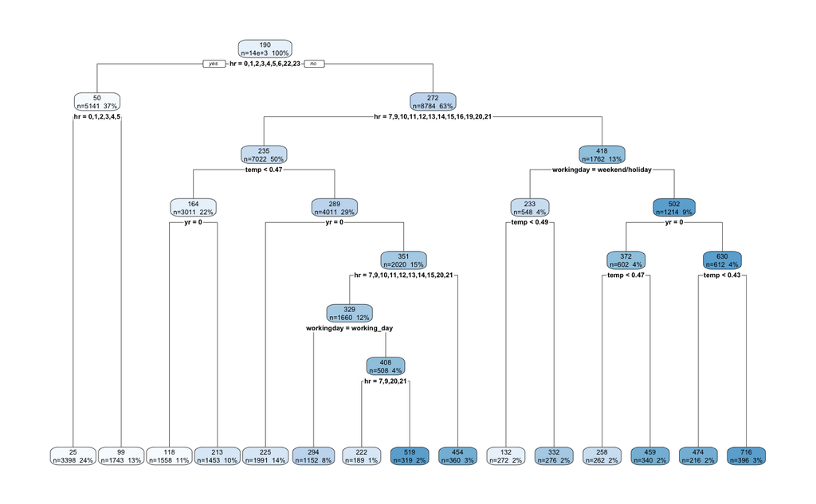

```r
rpart.plot(full_rt, extra = 101,)
```

[output not shown]

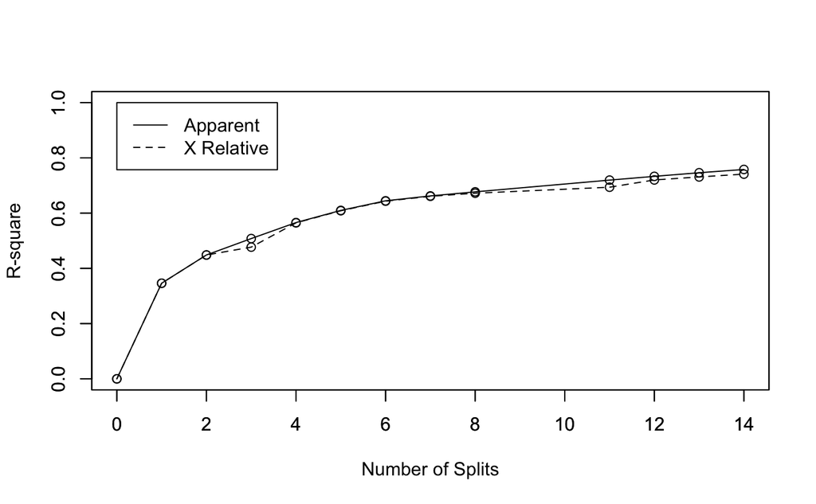

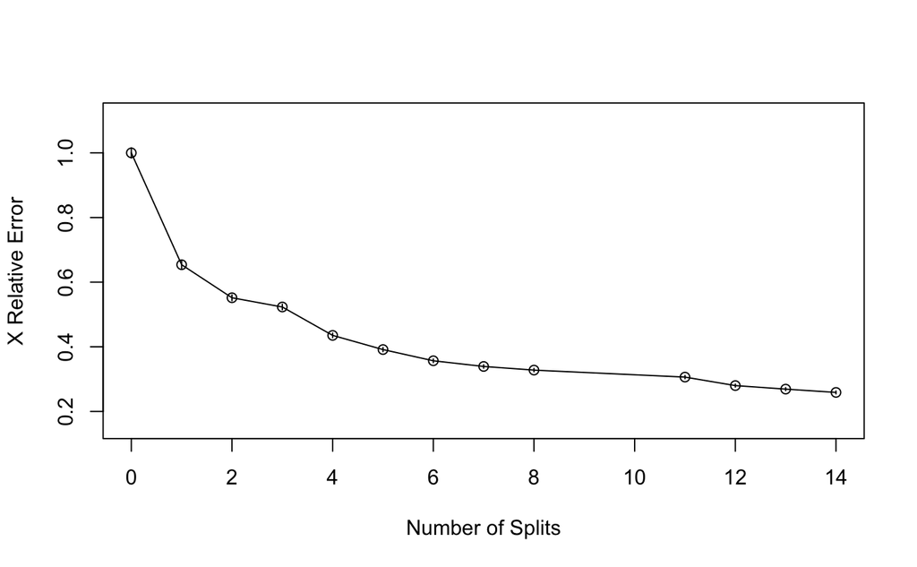

```r
rsq.rpart(full_rt)
```

```r
pruned_rt <- prune(full_rt, cp = 0.044033)
```

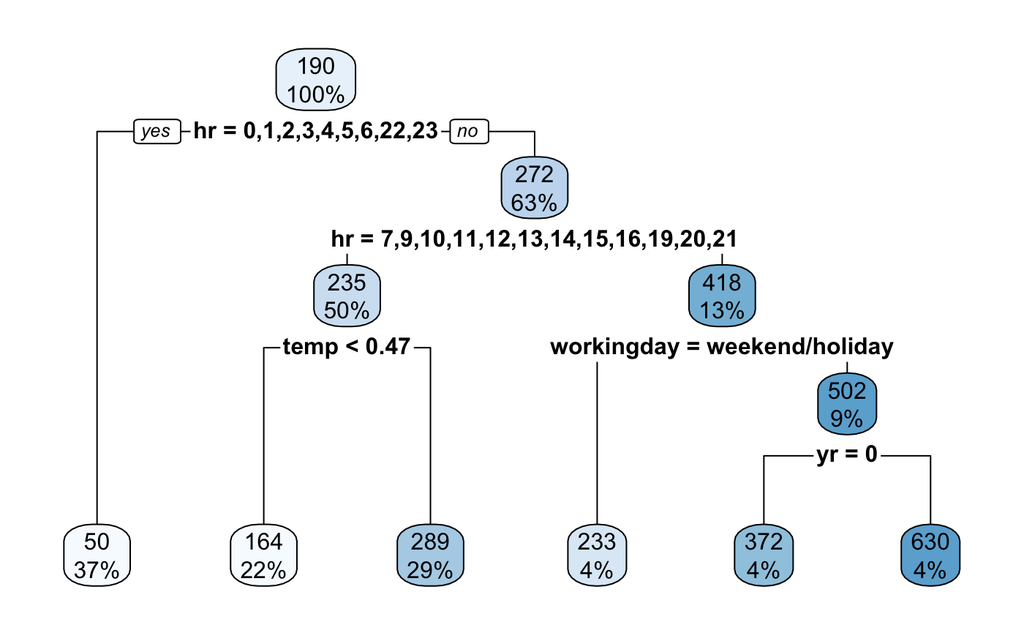

```r
rpart.plot(pruned_rt)
```

## Random forest

```r
rrf <- randomForest(cnt ~.,
                    data = train_data,
                    mtry = 4,
                    importance = TRUE
                    )
```

```r
rrf
```

```
Call:
 randomForest(formula = cnt ~ ., data = train_data, mtry = 4,      importance = TRUE)
               Type of random forest: regression
                     Number of trees: 500
No. of variables tried at each split: 4

          Mean of squared residuals: 2336.046
                    % Var explained: 92.95
```

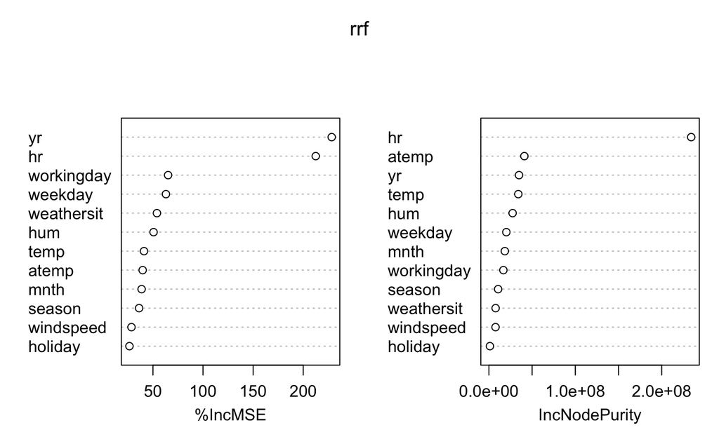

```r
varImpPlot(rrf)
```

```r
importance(rrf)
```

```
             %IncMSE IncNodePurity
season      36.17111      10660647
yr         228.41064      34848546
mnth        38.68979      18381643
hr         212.47504     234124681
holiday     26.53114       1139391
weekday     62.97866      20153054
workingday  65.13580      16736194
weathersit  53.97868       7753768
temp        41.06882      34006466
atemp       39.73952      41017747
hum         50.61156      27408835
windspeed   28.56683       7647619
```

mtry = 4

In decision tree algorithms, “mtry” represents the number of randomly selected features considered at each node when building a tree. Setting mtry to 4 means that, at each node, the algorithm selects 4 features from the dataset and evaluates them for the best split. This randomness helps prevent overfitting and enhances the model’s ability to generalize to new data.

- **Hour (hr)**:
  - %IncMSE: 212.47504
  - IncNodePurity: 234124681
  - The high %IncMSE value for the ‘hour’ variable suggests that the hour of the day is a crucial predictor in the model. An increase in the hour leads to a substantial increase in Mean Squared Error, indicating that this variable contributes significantly to the model’s predictive power. The corresponding IncNodePurity value reinforces this, indicating that splits based on the hour in the decision tree contribute to increased node purity.
- **Year (yr)**:
  - %IncMSE: 228.41064
  - IncNodePurity: 34848546
  - The ‘year’ variable also has a high %IncMSE value, indicating that it is an important predictor. An increase in the year contributes significantly to the model’s predictive performance. The IncNodePurity value suggests that splits based on the year contribute to improved node purity in the decision tree.
- **Temperature (temp)**:
  - %IncMSE: 41.06882
  - IncNodePurity: 34006466
  - The ‘temp’ variable has a moderate %IncMSE value, suggesting that it is an important predictor for the model. An increase in temperature contributes to an increase in Mean Squared Error, indicating its relevance in predicting the target variable. The IncNodePurity value also supports the importance of ‘temp’ in decision tree splits.

# Model Evaluations

## Predictions

```r
predlm <- predict(stepwise_lm, newdata = test_data)
predrt <- predict(pruned_rt, newdata = test_data)
predrrf <- predict(rrf, newdata = test_data)
```

## Results

```r
resultslm <- postResample(predlm, test_data$cnt)
resultsrt <- postResample(predrt, test_data$cnt)
resultsrrf <- postResample(predrrf, test_data$cnt)
```

```r
resultslm
```

```
       RMSE    Rsquared         MAE
100.7249812   0.6828328  74.4598580
```

```r
resultsrt
```

```
       RMSE    Rsquared         MAE
112.5128137   0.6033501  82.0715589
```

```r
resultsrrf
```

```
      RMSE   Rsquared        MAE
46.0671290  0.9395406 31.0706531
```

**RANDOM FOREST HAS THE BEST PERFORMANCE**

**RANDOM FOREST**

- **Root Mean Squared Error (RMSE)**:
  - Value: 46.0671290
  - Interpretation: RMSE represents the square root of the average squared differences between the predicted values and the actual values. Lower RMSE values indicate better model performance, as they suggest that, on average, the model’s predictions are closer to the actual values.
- **R-squared (Rsquared)**:
  - Value: 0.9395406
  - Interpretation: R-squared is a measure of the proportion of the variance in the dependent variable that is explained by the model. In this case, an R-squared of 0.9395406 suggests that approximately 94% of the variance in the bike rental count is explained by the Random Forest model. Higher R-squared values indicate better goodness of fit, meaning that the model captures a large portion of the variability in the target variable.
- **Mean Absolute Error (MAE)**:
  - Value: 31.0706531
  - Interpretation: MAE represents the average absolute differences between the predicted values and the actual values. In Random Forest model an MAE of 31.07 indicates the average magnitude of the errors in predicting bike rental counts. Like RMSE, lower MAE values are desirable, as they suggest that, on average, the model’s predictions are closer to the actual values

## Actual target value / Predicted value

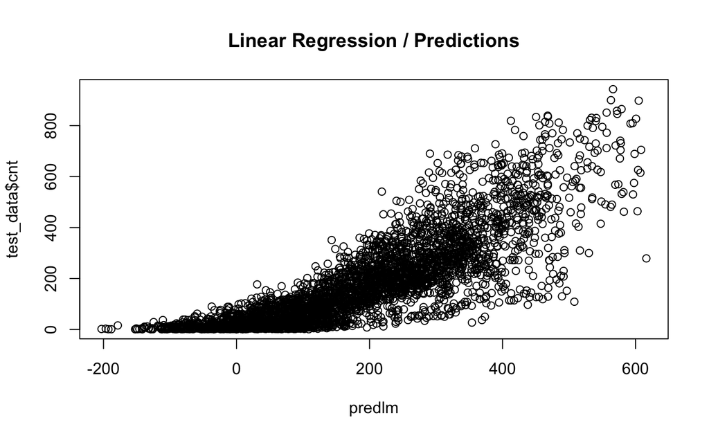

```r
plot(x=predlm, test_data$cnt, main = 'Linear Regression / Predictions')
```

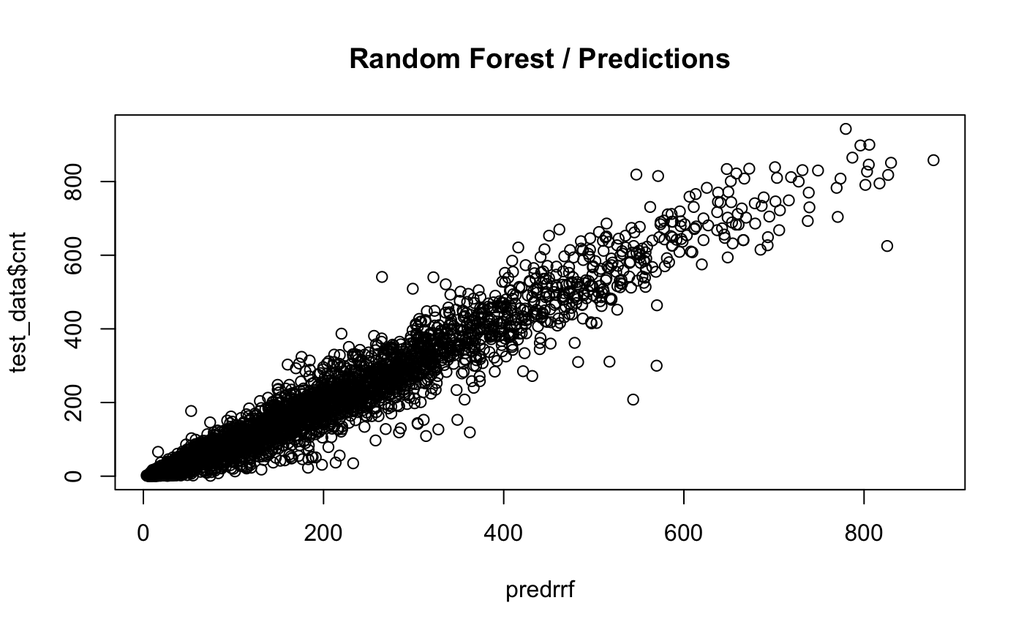

```r
plot(x=predrrf, y=test_data$cnt, main = 'Random Forest / Predictions')
```

These two plots showcase the better fit of Random Forest over the Linear Regression.